# 🧠 **Inteligencia Artificial y Machine Learning**

### 📌 Introducción

📖 Definición clásica:  
*“La ciencia e ingeniería de hacer máquinas inteligentes.”*  
— *John McCarthy (1956)*

La **Inteligencia Artificial (IA)** es una rama de la informática que busca crear sistemas capaces de imitar o reproducir comportamientos inteligentes, como el razonamiento, la resolución de problemas, la percepción o el aprendizaje.

En otras palabras, la IA intenta que las máquinas puedan realizar tareas que normalmente requieren de la inteligencia humana, como reconocer imágenes, entender el lenguaje o tomar decisiones.

Su objetivo principal es desarrollar programas y algoritmos que permitan a las computadoras adaptarse, aprender de la experiencia y mejorar su rendimiento con el tiempo.

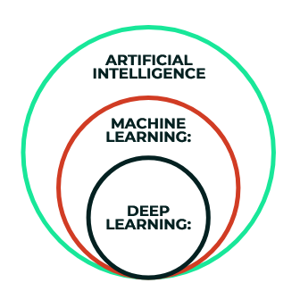

Dentro de la IA, uno de los campos más importantes es el **Machine Learning (aprendizaje automático)**. Este se centra en diseñar modelos y técnicas que permitan a las computadoras aprender a partir de datos, sin necesidad de ser programadas explícitamente para cada tarea.

Por ejemplo, un sistema de Machine Learning puede aprender a recomendar películas, identificar rostros o predecir precios de mercado analizando información previa.

En resumen, mientras la IA busca crear "máquinas inteligentes", el Machine Learning proporciona las herramientas para que estas máquinas aprendan por sí mismas.

## 🎯 Objetivos de la Inteligencia Artificial

- Automatizar tareas cognitivas humanas
- Crear sistemas adaptativos (aprendizaje)
- Desarrollar agentes inteligentes autónomos
- Comprender la inteligencia humana desde una perspectiva computacional

## 📚 Clasificación de la IA

**Según su capacidad:**

- 🔹 *IA Débil:* especializada en tareas específicas (e.g., Siri)
- 🔹 *IA Fuerte:* inteligencia general humana (aún en desarrollo)
- 🔹 *IA Superinteligente:* supera la inteligencia humana (teórico)

**Según su funcionalidad:**

- 🔸 Sistemas reactivos (sin memoria)
- 🔸 Memoria limitada (aprenden del pasado)
- 🔸 Teoría de la mente (futuro)
- 🔸 Autoconciencia (futuro)

### 🔬 Disciplinas Relacionadas con la IA

- Matemáticas (probabilidad, álgebra lineal)
- Estadística y Machine learning
- Teoría de la computación y lógica
- Neurociencia y psicología cognitiva
- Lingüística computacional

### 🧩 Subcampos de la Inteligencia Artificial

- 🤖 Aprendizaje automático (Machine Learning)
- 🗣 Procesamiento de Lenguaje Natural (NLP)
- 👁 Visión por Computador
- 🔧 Robótica
- 🧠 Sistemas Expertos

## 🕰 Historia de la Inteligencia Artificial (Ampliada)

La historia de la Inteligencia Artificial abarca más de siete décadas de desarrollo. A continuación, se presenta una cronología más detallada:

#### 🧪 **Década de 1940–1950: Fundamentos**

- **1943:** McCulloch y Pitts desarrollan un modelo matemático de la neurona.
- **1950:** Alan Turing publica “Computing Machinery and Intelligence” y propone el famoso *Test de Turing*.

#### 🤖 **Década de 1950–1960: Nacimiento del campo**

- **1956:** Conferencia de Dartmouth. John McCarthy acuña el término "Inteligencia Artificial".
- **1958:** John McCarthy desarrolla el lenguaje de programación LISP, esencial en IA durante décadas.
- **1959:** Arthur Samuel crea un programa que juega damas y mejora con la experiencia (*machine learning* temprano).

#### 🧠 **Década de 1960–1970: Primeros logros**

- Se desarrollan sistemas que resuelven problemas algebraicos y juegos de mesa.
- Surge ELIZA, un programa pionero de procesamiento de lenguaje natural que simula una conversación con un terapeuta.

#### 📉 **Década de 1970–1980: Primera “IA Winter”**

- Las expectativas sobre la IA no se cumplen.
- El financiamiento para investigación disminuye drásticamente.

#### 💡 **Década de 1980–1990: Sistemas Expertos y Resurgimiento**

- Los sistemas expertos como MYCIN logran éxito en diagnóstico médico.
- La IA se usa en la industria (diagnóstico, ingeniería, minería de datos).
- Surge el concepto de "agentes inteligentes".

#### ❄️ **Década de 1990: Segunda “IA Winter”**

- Los sistemas expertos se muestran costosos y difíciles de mantener.
- Las expectativas nuevamente se reducen.

#### 💥 **1997: IA vence a los humanos**

- Deep Blue de IBM derrota al campeón mundial de ajedrez Garry Kasparov.

#### 📈 **Década de 2000: Auge del aprendizaje automático**

- Incremento del poder computacional y acceso a grandes volúmenes de datos.
- Se desarrollan algoritmos de *machine learning* más sofisticados.

#### 🤯 **2012: Renacimiento del Aprendizaje Profundo**

- AlexNet gana el concurso de reconocimiento de imágenes ImageNet usando redes neuronales profundas (Deep Learning).
- Se acelera la investigación en redes neuronales convolucionales y recurrentes.

#### 🎮 **2016: AlphaGo y la superación de lo humano**

- AlphaGo, desarrollado por DeepMind, vence al campeón mundial de Go, un juego considerado extremadamente complejo.

#### 🧠 **Década de 2020: IA Generativa y Modelos Fundacionales**

- Aparecen modelos de lenguaje como GPT-3 y GPT-4, capaces de generar texto, código y más.
- Modelos multimodales como DALL·E, CLIP y Sora (video) amplían las capacidades de la IA.
- La IA se integra masivamente en productos de consumo, negocios, educación y arte.

#### 🔮 **Presente y Futuro**

- Se debate sobre la regulación, el impacto ético, y el potencial de una superinteligencia artificial.
- Continúan los avances en IA general, aprendizaje por refuerzo, neurociencia computacional y robótica cognitiva.

## 🧪 Aplicaciones de la Inteligencia Artificial

- 🏥 Salud: diagnóstico médico, análisis de imágenes
- 💸 Finanzas: detección de fraude, trading algorítmico
- 🎓 Educación: tutores inteligentes, personalización
- 🚗 Transporte: vehículos autónomos, rutas inteligentes
- 🌾 Agricultura: monitoreo de cultivos, predicción de cosechas
- 🎮 Entretenimiento: sistemas de recomendación, IA en juegos

## ⚖️ Ética y Desafíos de la IA

- 🔐 Privacidad y uso de datos
- 👨‍💼 Impacto laboral y reemplazo de empleos
- ⚖️ Discriminación algorítmica y sesgo
- 🧾 Regulación y responsabilidad
- 🤖 Control de sistemas autónomos

✅ Es esencial que el desarrollo de IA siga principios de equidad, transparencia y seguridad.

📌 **Próxima Clase:** Introducción al Aprendizaje Automático (Machine Learning)

# Bibliografía y material de apoyo

- C. Huyen, Designing machine learning systems. ” O’Reilly Media, Inc.”, 2022. [Designing machine learning systems](https://github.com/chiphuyen/dmls-book/blob/main/README.md)
- Algorithmia, “2020 state of enterprise machine learning,” 2020.
- [AI Index Report](https://hai.stanford.edu/ai-index)
- [3Blue1Brown](https://www.youtube.com/@3blue1brown)
- [Building A Generative AI Platform](https://huyenchip.com/2024/07/25/genai-platform.html)
- [Awful AI](https://github.com/daviddao/awful-ai?tab=readme-ov-file)